# Ch8: Tree-Based Methods

Philip Lin

2015.1.14

# Outline

- Motivation
- Regression tree
  - Tree growing
  - Tree pruning
  - Example: Boston house price
  - Bagging and Random Forest
- Classification tree
  - Impurity

# Motivation

Forget about all smoothing techniques, what will you do to fit a model on this data ?

i.e. estimate the function $f$ in $y = f(x)$

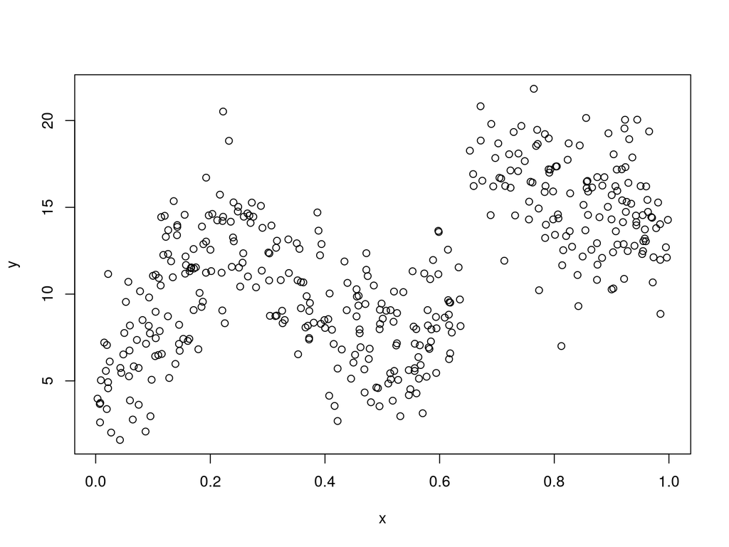

# Motivation

This model is seems well-fitted, however, it is not predictable.

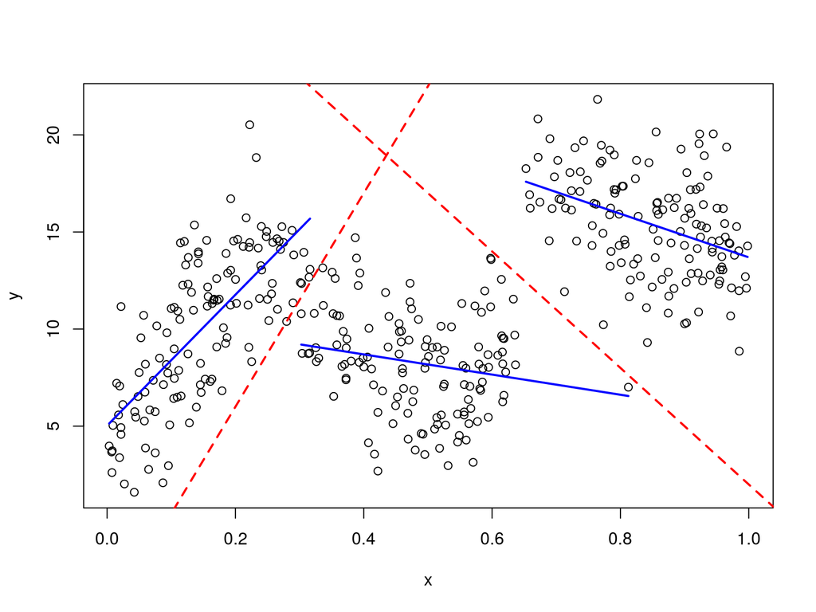

# Motivation

Now it can be used to do prediction, but can we do it in a simplier way ?

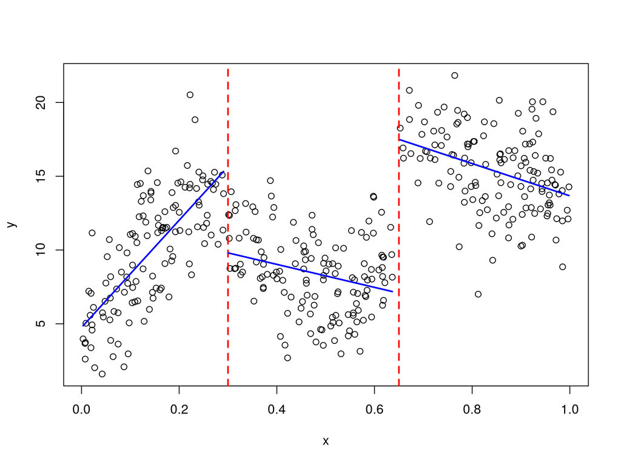

# Motivation

Now, it is simple enough. Can we write this model in a systemetic way ? (regression tree)

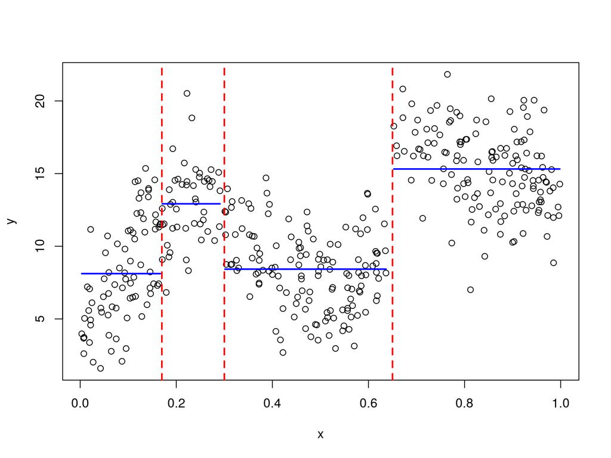

# Motivation

Another representation: regression tree

[figure not shown]

# Extend to p=2

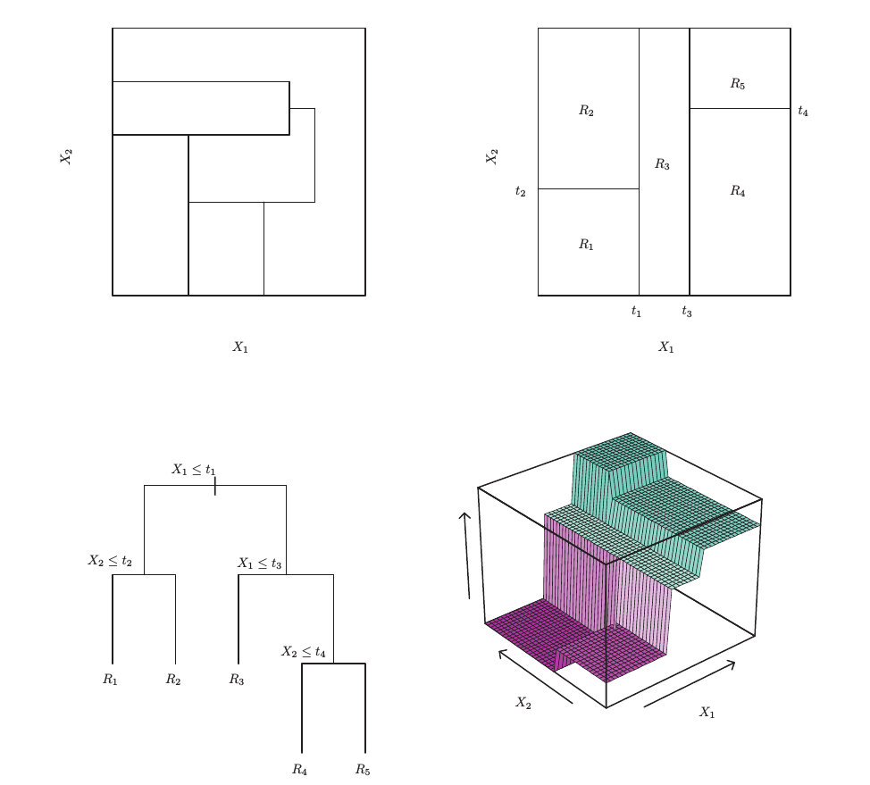

In top-left plot, it corresponds to the case that partitions in regression tree will perform poor.

# Tree growing

- Divide the predictor space into $J$ disjoint regions, or boxes, $R_1,\dots,R_J$. These boxes must minimize the RSS given by

$\sum_{j=1}^J\sum_{i\in R_j}(y_i-\hat{y}_{R_j})^2$ where $\hat{y}_{R_j}$ is the mean response for the observations in $j$th box.

- The first split
  - for any $j$ and $s$, define pair of half-planes $R_1(j,s)=\{X|X_j<s\} ~~\text{and}~~ R_2(j,s)=\{X|X_j\geq s\}$ and we seek the value of $j$ and $s$ that minimize the equation $\sum_{i:x_i\in R_1(j,s)}(y_i-\hat{y}_{R_1})^2 + \sum_{i:x_i\in R_2(j,s)}(y_i-\hat{y}_{R_2})^2$ where $\hat{y}_{R_1}$ and $\hat{y}_{R_2}$ are mean response in $R_1(j,s)$ and $R_2(j,s)$ respectively. (Note: in this step, finding the values of $j$ and $s$ that minimize the above objective function can be done quite quickly when $p$ is not too large.)
- The second split
  - Instetad of splitting the entire predictor space, we split one of the two previously identified regions. We know have three regions.
- The third split
  - Again, we look to split one of these three regions further, so as to minimize the RSS within each region.
- Keep doing until a stopping criterion is reached; for instance, we may continue until no region contains more than five observations.
- A full growing tree may produce good predictions on the training set, but it is also likely to overfit the data.

# Tree pruning

- A good strategy is to grow a very large tree $T_0$, and then prune it back in order to obtain a subtree.
- Idea: regularization, put an $l_0$ penalty on the number of node
- For each value of $\alpha$ there corresponds a subtree $T\subset T_0$ such that $\sum_{m=1}^{|T|}\sum_{i:x_i\in R_m}(y_i-\hat{y}_{R_m})^2 + \alpha|T|$ is as small as possible. Here $|T|$ indicates the number of terminal nodes of the tree $T$
- As we increase $\alpha$ from zero, branches get pruned from the tree in a nested and predictable fashion, so obtaining the whole sequence of subtrees as a function of $\alpha$ is easy.
- $\alpha$ can be selected by K fold CV.

# Example: House price in Boston

- This data frame contains the following columns:
  - crim: per capita crime rate by town.
  - zn: proportion of residential land zoned for lots over 25,000 sq.ft.
  - indus: proportion of non-retail business acres per town.
  - chas: Charles River dummy variable (= 1 if tract bounds river; 0 otherwise).
  - nox: nitrogen oxides concentration (parts per 10 million).
  - rm: average number of rooms per dwelling.
  - age: proportion of owner-occupied units built prior to 1940.
  - dis: weighted mean of distances to five Boston employment centres.
  - rad: index of accessibility to radial highways.
  - tax: full-value property-tax rate per $10,000.
  - ptratio: pupil-teacher ratio by town.
  - black: 1000(Bk - 0.63)^2, where Bk is the proportion of blacks by town.
  - lstat: lower status of the population (percent).
  - medv: median value of owner-occupied homes in $1000s.

```
        crim zn indus chas   nox    rm  age    dis rad tax ptratio  black
  1: 0.00632 18  2.31    0 0.538 6.575 65.2 4.0900   1 296    15.3 396.90
  2: 0.02731  0  7.07    0 0.469 6.421 78.9 4.9671   2 242    17.8 396.90
  3: 0.02729  0  7.07    0 0.469 7.185 61.1 4.9671   2 242    17.8 392.83
  4: 0.03237  0  2.18    0 0.458 6.998 45.8 6.0622   3 222    18.7 394.63
  5: 0.06905  0  2.18    0 0.458 7.147 54.2 6.0622   3 222    18.7 396.90
 ---
502: 0.06263  0 11.93    0 0.573 6.593 69.1 2.4786   1 273    21.0 391.99
503: 0.04527  0 11.93    0 0.573 6.120 76.7 2.2875   1 273    21.0 396.90
504: 0.06076  0 11.93    0 0.573 6.976 91.0 2.1675   1 273    21.0 396.90
505: 0.10959  0 11.93    0 0.573 6.794 89.3 2.3889   1 273    21.0 393.45
506: 0.04741  0 11.93    0 0.573 6.030 80.8 2.5050   1 273    21.0 396.90
     lstat medv
  1:  4.98 24.0
  2:  9.14 21.6
  3:  4.03 34.7
  4:  2.94 33.4
  5:  5.33 36.2
 ---
502:  9.67 22.4
503:  9.08 20.6
504:  5.64 23.9
505:  6.48 22.0
506:  7.88 11.9
```

# Example: House price in Boston

```r
library(tree)
set.seed(1)
train = sample(1:nrow(Boston), nrow(Boston)/2)
tree.boston=tree(medv~.,Boston, subset=train)
summary(tree.boston)
```

```
Regression tree:
tree(formula = medv ~ ., data = Boston, subset = train)
Variables actually used in tree construction:
[1] "lstat" "rm"    "dis"
Number of terminal nodes:  8
Residual mean deviance:  12.65 = 3099 / 245
Distribution of residuals:
     Min.   1st Qu.    Median      Mean   3rd Qu.      Max.
-14.10000  -2.04200  -0.05357   0.00000   1.96000  12.60000
```

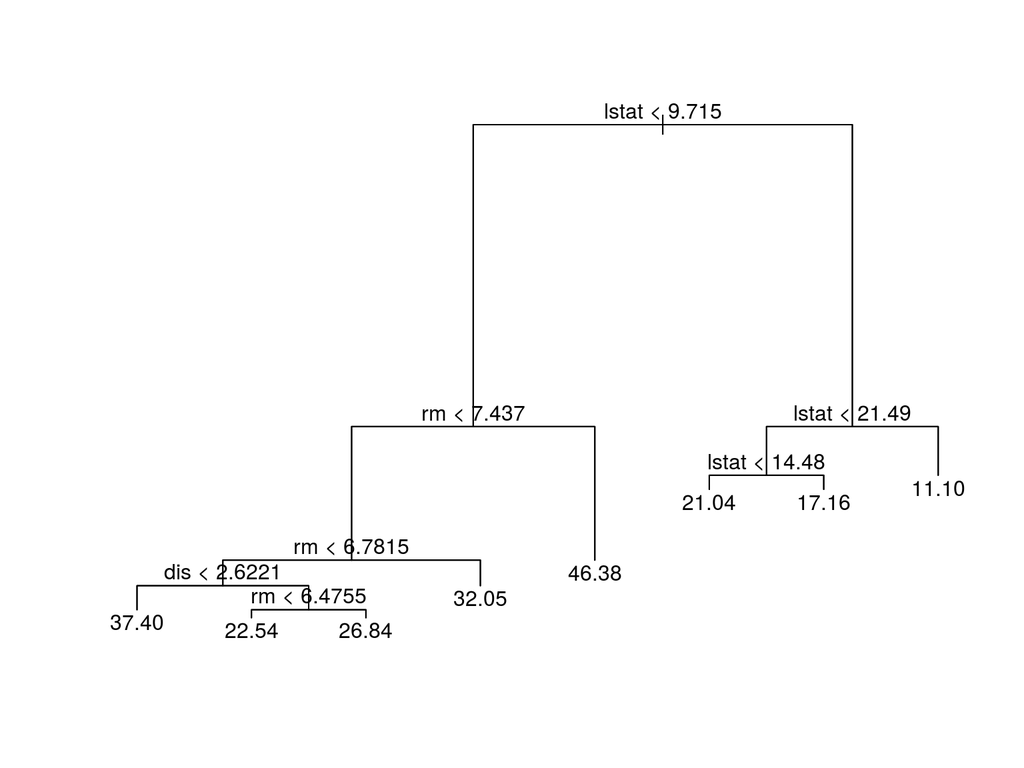

```r
plot(tree.boston)
text(tree.boston, pretty=NULL)
```

```r
tree.boston
```

```
node), split, n, deviance, yval
      * denotes terminal node

 1) root 253 20890.0 22.67
   2) lstat < 9.715 103  7765.0 30.13
     4) rm < 7.437 89  3310.0 27.58
       8) rm < 6.7815 61  1995.0 25.52
        16) dis < 2.6221 5   615.8 37.40 *
        17) dis > 2.6221 56   610.3 24.46
          34) rm < 6.4755 31   136.4 22.54 *
          35) rm > 6.4755 25   218.3 26.84 *
       9) rm > 6.7815 28   496.6 32.05 *
     5) rm > 7.437 14   177.8 46.38 *
   3) lstat > 9.715 150  3465.0 17.55
     6) lstat < 21.49 120  1594.0 19.16
      12) lstat < 14.48 62   398.5 21.04 *
      13) lstat > 14.48 58   743.3 17.16 *
     7) lstat > 21.49 30   311.9 11.10 *
```

# Example: House price in Boston

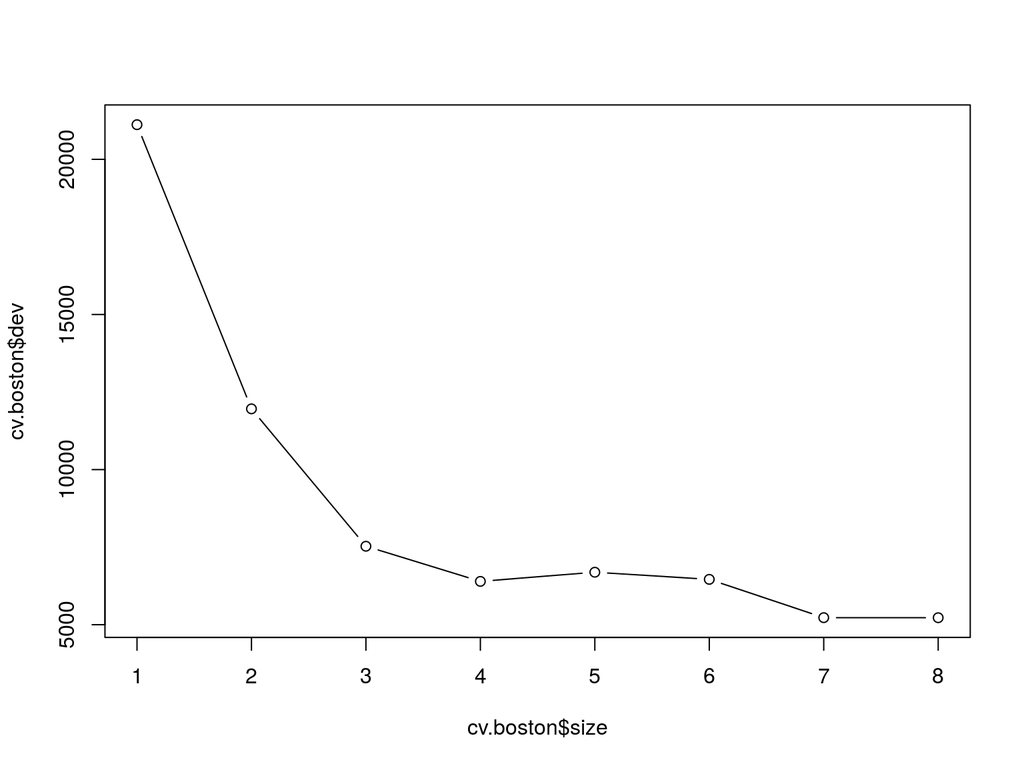

```r
cv.boston=cv.tree(tree.boston, K=10)
plot(cv.boston$size, cv.boston$dev, type="b")
```

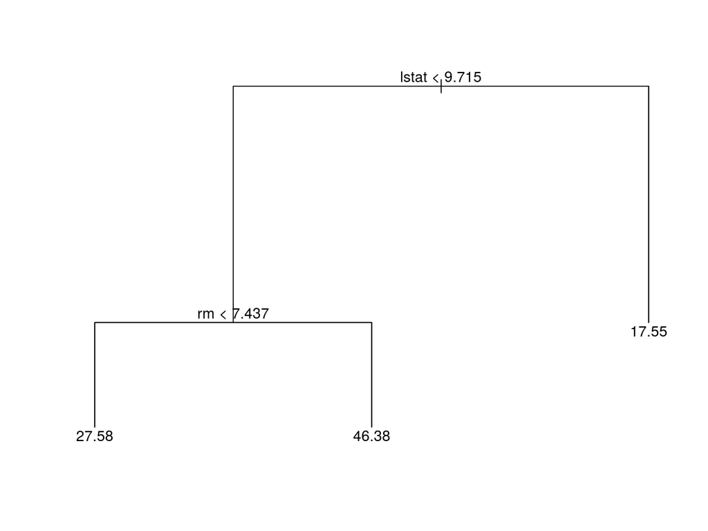

```r
prune.boston <- prune.tree(tree.boston, best=3)
plot(prune.boston)
text(prune.boston, pretty=0)
```

- Trees are very easy to explain to people. In fact, they are even easier to explain than linear model.
- Some people believe that decision trees more closely mirror human decision-making than do the regression.

# Example: House price in Boston (prediction)

```r
yhat=predict(tree.boston, newdata=Boston[-train,])
boston.test=Boston[-train,"medv"]
mean((yhat-boston.test)^2)
```

```
[1] 25.04559
```

Let’s compare the prediction performance to that in Lasso

```r
library(glmnet)
x.train <- as.matrix(Boston[train,-14])
y.train <- Boston$medv[train]
cv.mod <- cv.glmnet(x.train, y.train, nfolds=10)
mod <- glmnet(x.train, y.train, lambda=cv.mod$lambda.min)

mod$beta
```

```
13 x 1 sparse Matrix of class "dgCMatrix"
                   s0
crim     -0.112650956
zn        0.054094302
indus     0.038162091
chas      3.547895113
nox     -15.056744531
rm        3.304086650
age      -0.004759273
dis      -1.769689826
rad       0.307875605
tax      -0.011880112
ptratio  -0.915273705
black     0.008700221
lstat    -0.657498486
```

```r
x.test <- as.matrix(Boston[-train,-14])
yhat <- predict(mod, newx=x.test)
mean((yhat-boston.test)^2)
```

```
[1] 26.22887
```

- This book says “Unfortunately, trees generally do not have the same level of predictive accuracy as some of the other regression and classification approaches seen in this book”.
- Trees performs better than Lasso in this example. It indicates the effect of covariates on response is probably non-linear.

# Bagging and Random forest

- If we focus on the prediction performance, without any caring about interpretation, what can we do furhter ?
  - We can grow our tree as large as possible to improve the ability in prediction. However, this large tree suffers from high variance.
  - Bagging, random forest and Boosting
- Basic idea of bagging: given $n$ independent observations $Z_1,\dots,Z_n$, each with variance $\sigma^2$, the variance of the mean $\bar{Z}$ of the observations is given by $\sigma^2/n$
- Extend this idear to regression tree:
  - Obtain $B$ bootstrap sample from training set
  - Calculate $\hat{f}^1(x), \dots, \hat{f}^B(x)$ using $B$ separate training sets.
  - Average them $\hat{f}_{\text{avg}}(x) = \frac{1}{B}\sum_{b=1}^B\hat{f}^b(x)$

# Bagging and random forest

- Note that there are two problems in bagging
  1. Suppose there is one strong covariate affect response mostly, the strong covariates is believed to exist consistently and be used in the top split in each bootstrap sample. It leads to similar structure among different bootstraped trees and will not significantly reduce prediction error.
  2. After finishing bagging, how to evaluate prediction error ?
- To solve 1., in each bootstrap sample, fit tree with a **random sample of $m$ predictors ($m\approx \sqrt{p}$)**
  - The algorithm decorrelates the bagged trees
  - On average $\frac{{p-1 \choose m}}{{p \choose m}} = 1-\frac{m}{p}$ of bootstraped trees will not even consider ther strong predictor.
- To solve 2., there is a trick to calcute prediction error: **out-of-bag error estimation**
  - Given data $x_1,\dots,x_n$, we take length $n$ resampling (sample with replacement) from $\{x\}$, denoted as $S$, what is the probability of $x_j$ does not exist in this sample $S$? $p(x_j\not\in S)=\frac{(n-1)^n}{n^n}=\left(1-\frac{1}{n}\right)^n, j=1,\dots,n$
  - On average, each bagged tree makes use of around two-thirds of the observations. Therefore, we can use remaining one-third out-of-bag observations as testing data.

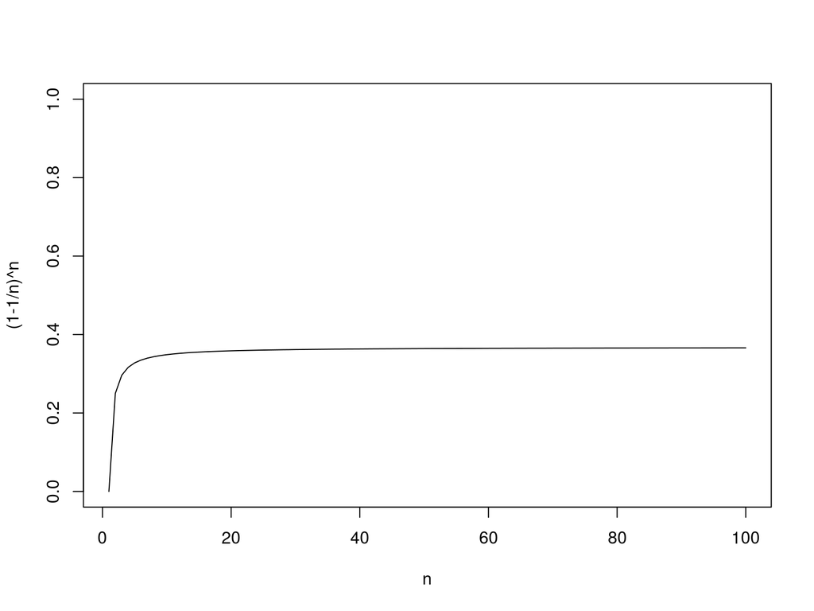

# Bagging and random forest

```r
library(randomForest)
set.seed(1)
bag.boston=randomForest(medv~., data=Boston, subset=train,
                        mtry=13, # Number of variables randomly sampled as candidates at each split
                        importance=TRUE)
bag.boston
```

```
Call:
 randomForest(formula = medv ~ ., data = Boston, mtry = 13, importance = TRUE,      subset = train)
               Type of random forest: regression
                     Number of trees: 500
No. of variables tried at each split: 13

          Mean of squared residuals: 11.02509
                    % Var explained: 86.65
```

```r
yhat.bag <- predict(bag.boston, newdata=Boston[-train,])
mean((yhat.bag-boston.test)^2)
```

```
[1] 13.47349
```

# Bagging and random forest

```r
set.seed(1)
rf.boston=randomForest(medv~.,data=Boston,subset=train,mtry=6,importance=TRUE)
yhat.rf=predict(rf.boston,newdata=Boston[-train,])
mean((yhat.rf-boston.test)^2)
```

```
[1] 11.48022
```

```r
importance(rf.boston)
```

```
          %IncMSE IncNodePurity
crim    12.547772    1094.65382
zn       1.375489      64.40060
indus    9.304258    1086.09103
chas     2.518766      76.36804
nox     12.835614    1008.73703
rm      31.646147    6705.02638
age      9.970243     575.13702
dis     12.774430    1351.01978
rad      3.911852      93.78200
tax      7.624043     453.19472
ptratio 12.008194     919.06760
black    7.376024     358.96935
lstat   27.666896    6927.98475
```

# Classification tree

- The story is same as in regression tree except the evaluation of error rate, we denote it as **node impurity**.
- Given node $\tau$, let $\pi_j$ be the $j_{th}$ class, $j=1,\dots,K; K\geq 2$. The impurity function is defined as $i(\tau)=\phi(p(1|\tau),\dots,p(K|\tau))$ where $p(j|\tau)$ is an estimate of $P(X\in\pi_j)$, the conditional probability that an observation $X$ is in $\pi_j$ given that it falls into node $\tau$.
- A good impurity function should satisfiy the following three properties:
  1. $\phi$ is symmetric
  2. $\phi$ is maximized at $(\frac{1}{K},\dots,\frac{1}{K})$
  3. $\phi$ is minimized at $(1,0,\dots,0), (0,1,\dots,0), (0,0,\dots,1)$

# Impurity functions

- Misclassification rate $1-\max_{j=1,\dots,K}p(j|\tau)$
- Entropy function $\phi(p(1|\tau),\dots,p(K|\tau))=-\sum_{j=1}^K p(j|\tau)\log p(j|\tau)$
- Gini function $\phi(p(1|\tau),\dots,p(K|\tau))=\sum_{j=1}^K p(j|\tau)(1-p(j|\tau))$

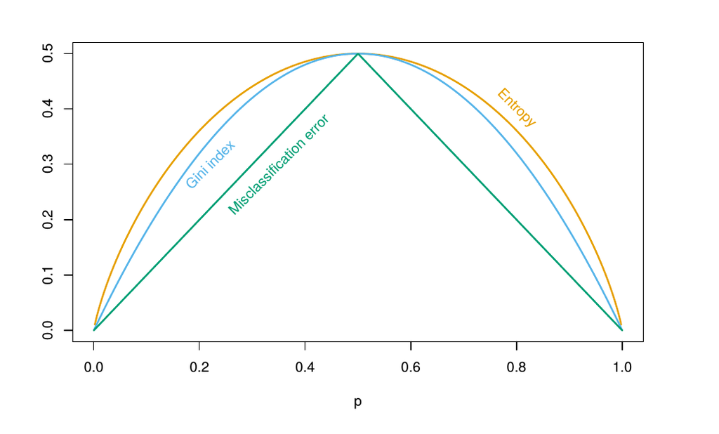

- The goodness of split $s$ at node $\tau$ is given the reduction in impurity gained by splitting the parent node $\tau$ into $\tau_R$ and $\tau_L$ $\triangle i(s,\tau) = i(\tau)-i(\tau_L)-i(\tau_R)$ The best split for the single variable $X_j$ is the one that has largest value of $\triangle i(s,\tau)$ over all $s\in \mathcal{S}_j$

# What are we going to do ?

$y = f(X) + \epsilon$

- Unsupervised learning
  - Unsupervised Learning (Ch10)
- Supervised learning (Inference purpose)
  - Linear regression (Ch3)
  - Classification (Ch4)
  - Resampling method (Ch5)
  - Linear model selection and regularization (Ch6)
  - Moving beyond linearity (Ch7)
- Supervised learning (Prediction purpose)
  - Tree based method (Ch8)
  - Support Vector Machine (Ch9)